# Coursera Prediction Assignment

Charmaine Hough

2 October 2016

## Introduction

##### Using devices such as Jawbone Up, Nike FuelBand, and Fitbit it is now possible to collect a large amount of data about personal activity relatively inexpensively. This study collected data from accelerometers worn on the belt, forearm, arm, and dumbell from 6 participants. Participants were asked to perform barbell lifts correctly and incorrectly in 5 different ways. The aim of this analysis was to quantify how well these exercises were performed.

## Load libraries required for analyses

```r
library(caret)
library(dplyr)
library(tidyr)
library(rattle)
```

```r
library(rpart.plot)
```

## Load in training and testing csv file

```r
dat_training <- read.csv("C://Users/ctam0304.MCS/Desktop/datasciencecoursera/8.PracticalMachineLearning/pml-training.csv")
dat_testing <- read.csv("C://Users/ctam0304.MCS/Desktop/datasciencecoursera/8.PracticalMachineLearning/pml-testing.csv")
```

## Data cleaning

#### Remove all variables that contain NA and remove the 1st 7 features as they are not numeric

```r
features <- names(dat_testing[,colSums(is.na(dat_testing)) == 0])[8:59]
```

#### Only include features in the testing set in the training set

```r
dat_training <- dat_training[,c(features,"classe")]
dat_testing <- dat_testing[,c(features,"problem_id")]
```

#### Checking the dimensions of training and testing sets

```r
dim(dat_training)
```

```
## [1] 19622    53
```

```r
dim(dat_testing)
```

```
## [1] 20 53
```

## Data partitioning

#### Make training and testing validation sets based on “classe” variable.The validation set will be used to assess the out of sample error for our model.

```r
set.seed(125)
inTrain <- createDataPartition(dat_training$classe, p=0.7,list=FALSE,times=1)
training <- dat_training[inTrain,]
testing = dat_training[-inTrain,]
```

## Building a decision tree model

#### Given that the outcome variable classe is a categorical variable, we will first use a decision tree model.

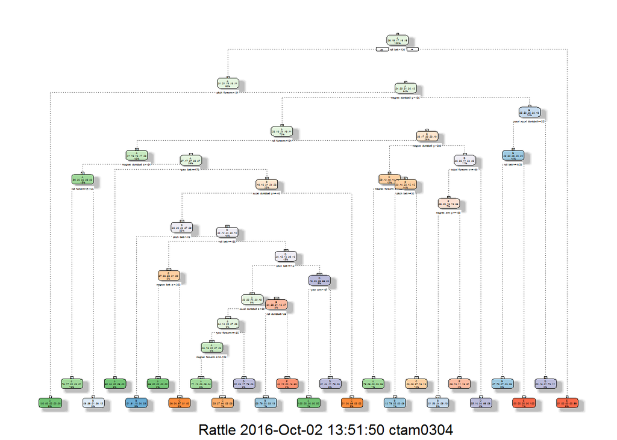

```r
modFitDT <- rpart(classe ~ ., data = training, method="class")
fancyRpartPlot(modFitDT)
```

#### Predict using the decision tree model on the validation set

```r
set.seed(125)
predDT <- predict(modFitDT, testing, type = "class")
confusionMatrix(predDT, testing$classe)
```

```
## Confusion Matrix and Statistics
##
##           Reference
## Prediction    A    B    C    D    E
##          A 1523  170   23   52   21
##          B   71  729   96   87  104
##          C   41  114  809  145  130
##          D   20   77   75  617   52
##          E   19   49   23   63  775
##
## Overall Statistics
##
##                Accuracy : 0.7567
##                  95% CI : (0.7455, 0.7676)
##     No Information Rate : 0.2845
##     P-Value [Acc > NIR] : < 2.2e-16
##
##                   Kappa : 0.6915
##  Mcnemar's Test P-Value : < 2.2e-16
##
## Statistics by Class:
##
##                      Class: A Class: B Class: C Class: D Class: E
## Sensitivity            0.9098   0.6400   0.7885   0.6400   0.7163
## Specificity            0.9368   0.9246   0.9115   0.9545   0.9679
## Pos Pred Value         0.8513   0.6707   0.6529   0.7337   0.8342
## Neg Pred Value         0.9631   0.9145   0.9533   0.9312   0.9381
## Prevalence             0.2845   0.1935   0.1743   0.1638   0.1839
## Detection Rate         0.2588   0.1239   0.1375   0.1048   0.1317
## Detection Prevalence   0.3040   0.1847   0.2105   0.1429   0.1579
## Balanced Accuracy      0.9233   0.7823   0.8500   0.7973   0.8421
```

##### Accuracy of decision tree model= 76%

## Building a random forest model

#### Build the model using random forest and perform predictions on the validation set.We selected k-fold=5 for performing cross validation

```r
set.seed(125)
fitControl<-trainControl(method="cv", number=5, allowParallel=T, verbose=T)
rffit<-train(classe~.,data=training, method="rf", trControl=fitControl, verbose=F)
predrf<-predict(rffit, newdata=testing)
confusionMatrix(predrf, testing$classe)
```

```
## Confusion Matrix and Statistics
##
##           Reference
## Prediction    A    B    C    D    E
##          A 1674    8    0    0    0
##          B    0 1128    8    0    1
##          C    0    3 1011   11    4
##          D    0    0    7  953    1
##          E    0    0    0    0 1076
##
## Overall Statistics
##
##                Accuracy : 0.9927
##                  95% CI : (0.9902, 0.9947)
##     No Information Rate : 0.2845
##     P-Value [Acc > NIR] : < 2.2e-16
##
##                   Kappa : 0.9908
##  Mcnemar's Test P-Value : NA
##
## Statistics by Class:
##
##                      Class: A Class: B Class: C Class: D Class: E
## Sensitivity            1.0000   0.9903   0.9854   0.9886   0.9945
## Specificity            0.9981   0.9981   0.9963   0.9984   1.0000
## Pos Pred Value         0.9952   0.9921   0.9825   0.9917   1.0000
## Neg Pred Value         1.0000   0.9977   0.9969   0.9978   0.9988
## Prevalence             0.2845   0.1935   0.1743   0.1638   0.1839
## Detection Rate         0.2845   0.1917   0.1718   0.1619   0.1828
## Detection Prevalence   0.2858   0.1932   0.1749   0.1633   0.1828
## Balanced Accuracy      0.9991   0.9942   0.9908   0.9935   0.9972
```

##### The acccuracy of the random forest model is 99% with a 95% CI of [0.99,0.9946] showing that is the random forest model is highly accurate.

## Conclusions and generating predictions on test dataset

##### As the random forest model presented with a higher accuracy, we used it to generate the predictions on the test dataset

```r
pred20<-predict(rffit, newdata=dat_testing)
```

# Output for the prediction of the 20 cases

```r
pred20
```

```
##  [1] B A B A A E D B A A B C B A E E A B B B
## Levels: A B C D E
```